# 2020-2021 Exame Especial 20-21 de Bioestatística

JP Cruz and A Freitas

3/09/2021

### Instruções e Anotações

- Esta secção não aparece ao aluno.

Escrever matemática assim para que no moodle se veja bem:

\( \beta_0 \)

Todas, atenção **todas**, as secções com # serão usadas como “Questão”.

O formato é:

- `# Capítulo X (alínea?) - descrição - ESSAY`
- `# Capítulo X (alínea?) - descrição - NUMERICAL`
- `# Capítulo X (alínea?) - descrição - MULTICHOICE`
- `# Capítulo X (alínea?) - descrição - CLOZE`

Interpretação:

- `#` quer dizer questão
- entre `#` e `##` é uma zona de texto e comandos que o aluno não vai ver; serve para produzir ou documentar a questão.
- `##` o texto da questão que o aluno vai ver; esta secção chama-se “variante” e mesmo que seja só uma deve existir (senão o aluno nada lê)
- `###` apenas nas respostas da variante (casos NUMERICAL e MULTICHOICE)
- `###` se existir, este segundo `###` indica o feedback da variante.

Seguem exemplos.

# Capítulo 1 - medidas - ESSAY

Daqui até `##` é uma zona de leitura/geração de dados e experimentação de cada questão que não passa para o moodle. Os resultados, após `knitr`, só são visíveis se em cima se ativar o modo “CONSTRUÇÃO” do teste:

Dados fixos:

**Outras ideias para questões**

- Indique, **justificando**, o valor lógico da frase: “Podemos concluir que em pelo menos 75% dos anos em estudo registaram-se menos de 50 novos produtos oriundos de agricultura biológica.”

| ano | 1993 | 1994 | 1995 | 1996 | 1997 | 1998 | 1999 | 2000 | 2001 | 2002 | 2003 | 2004 | 2005 |
| --- | --- | --- | --- | --- | --- | --- | --- | --- | --- | --- | --- | --- | --- |
| x | 10 | 50 | 40 | 71 | 72 | 70 | 69 | 50 | 73 | 76 | 70 | 80 | 78 |

## variante única

O uso de boas práticas de gestão da exploração agrícola tem demonstrado tendência para um crescente desenvolvimento da agrícultura biológica, fomentando deste modo a biodiversidade, os ciclos biológicos e a atividade biológica do solo.

Considere a variável X que representa o número de novos produtos que entram no mercado em cada ano oriundos de agrícultura biológica.

A seguinte tabela indica os valores de X observados de 1993 a 2005:

| ano | 1993 | 1994 | 1995 | 1996 | 1997 | 1998 | 1999 | 2000 | 2001 | 2002 | 2003 | 2004 | 2005 |
| --- | --- | --- | --- | --- | --- | --- | --- | --- | --- | --- | --- | --- | --- |
| x | 10 | 50 | 40 | 71 | 72 | 70 | 69 | 50 | 73 | 76 | 70 | 80 | 78 |

Considere a seguinte caixa-de-bigodes:

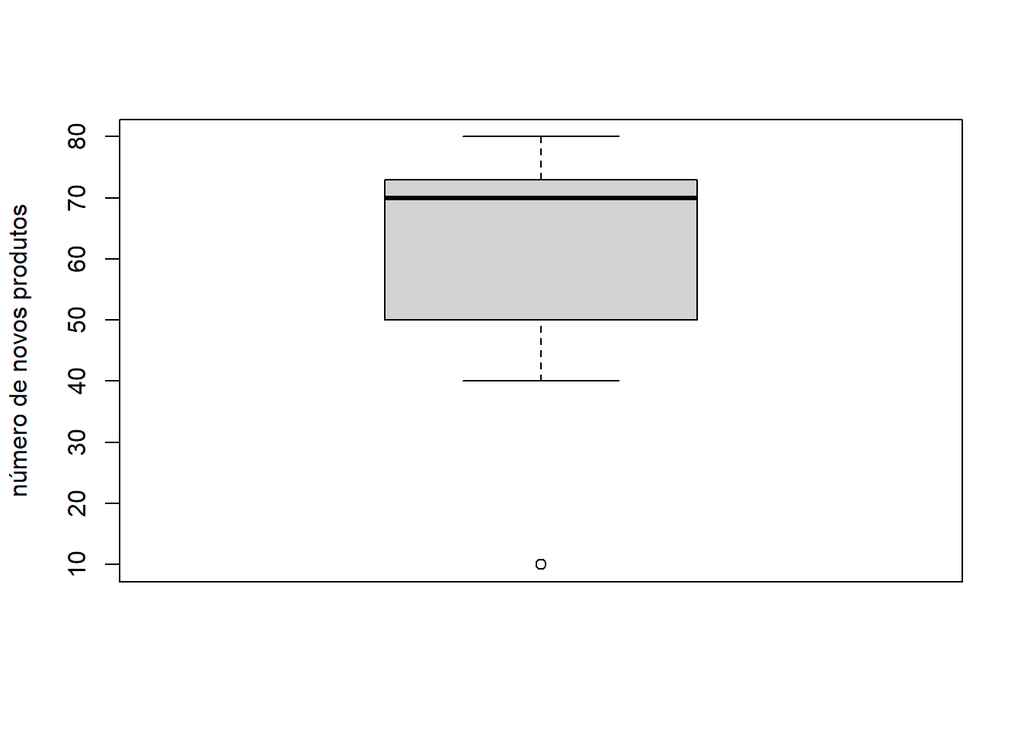

**(i)** Determine o terceiro quartil recorrendo a cálculos apropriados sobre a amostra, devendo justificar como encontra o seu valor.

**(ii)** Indique o primeiro quartil e diga o que significa.

*(iii)* Considere a caixa-de-bigodes dos dados. Responda, justificando, qual o valor atípico e uma possível explicação para esse valor ter ocorrido.

**(iv)** Considere a caixa-de-bigodes dos dados e responda justificando o que indica a linha escura no gráfico? (responda cuidadosamente no contexto do problema efetuando todas as interpretações possíveis)

**(v)** O que pode concluir sobre a simetria da distribuição? (justifique)

### feedback

(Consulte o docente se necessário.)

# Capítulo 2 (a) - Poisson - NUMERICAL

## variante única

Admite-se que, em 2011, o número de produtos de agricultura biológica comprados por agregado familiar e por semana, seja modelado por uma distribuição de Poisson de média 3 (unidades).

Determine a probabilidade de serem compradas, semanalmente e por família, mais de 5 unidades (estritamente).

(Use 4 casas decimais e vírgula nas respostas numéricas.)

### respostas

- “answer”: 0.0839179, “tol”: 0.01, “fraction”: 100, “feedback” : “Resposta correta.”
- “answer”: 0.1847368, “tol”: 0.01, “fraction”: 50, “feedback” : “1-P(X<=5) e não <=4.”
- “answer”: 0.9160821, “tol”: 0.01, “fraction”: 25, “feedback” : “‘Mais de 5’ começa no 6, 7, 8, … .”

### feedback

Em notação R: `1-ppois(5, lambda=3)`

# Capítulo 2 (b) - normal de barra X - NUMERICAL

## variante única

**Repetição do contexto anterior.** Admite-se que, em 2011, o número de produtos de agricultura biológica comprados por agregado familiar e por semana, seja modelado por uma distribuição de Poisson de média 3 (unidades).

**Questão:** Use o TLC para determinar a probabilidade de em 40 famílias, numa semana, serem consumidos entre 80 e 120 produtos de produção biológica.

(Use 4 casas decimais e vírgula.)

### respostas

- “answer”: 0.5180938, “tol”: 0.03, “fraction”: 100, “feedback” : “Resposta correta.”
- “answer”: 0.1305587, “tol”: 0.03, “fraction”: 50, “feedback” : “Faltou sqrt(VAR) para obter o desvio-padrão.”

### feedback

Do TLC:

- T = X1 + X40 aprox Normal(40 x 3, 40 x 3)

# Capítulo 2 (c) - TLC - MULTICHOICE

## variante única

Considere que se desconhece a real distribuição de X = **número de compras de embalagens de maças de agricultura biológica em 40 compras efetuadas por agregados familiares aleatórios**. A probabilidade de compra de embalagens de maças biológicas é 0.01.

A distribuição da v.a. X é

### respostas

- binomial;
- normal;
- Poisson;
- genérica e usa-se o TLC (n>30);

### feedback

X = número de ‘sucessos’ em n experiências aleatórias repetidas é sempre Binomial. Usa-se genérica quando não se consegue inferir a distribuição de uma v.a..

# Capítulo 3 - (usa dados do 4.1) IC com tinterval - NUMERICAL

IC TInterval = [ {:NUMERICAL:=12.3933298:0.1} , {:NUMERICAL:=16.5246702:0.1} ]

## variante única

Foram estudadas 20 árvores de produção de macieiras (Malus domestica) de agricultura biológica e para cada árvore foi pesado o total de frutos saudáveis. A média amostral, obtida sobre os 20 pesos, é 14.459 e o desvio padrão corrigido é 3.229.

Calcule um intervalo de confiança a 99% para o peso total médio de frutos saudáveis, por macieira, em agricultura biológica.

O **lado esquerdo** do IC é:

### respostas

- “answer”: 12.3933298, “tol”: 0.05, “fraction”: 100, “feedback” : “Resposta correta obtida com T Interval.”
- “answer”: 12.5991834, “tol”: 0.05, “fraction”: 50, “feedback” : “Resposta parcialmente correta pois foi obtida com Z Interval,”

### feedback

Realizar um T Interval sobre os dados porque se sabe que os dados são normais e com variância populacional desconhecida.

# Capítulo 4.1 - comparação de duas amostras independentes - ESSAY

## variante única

No sentido de demonstrar que a agricultura biológica também pode ser competitiva, comparou-se a produção de macieiras (Malus domestica) de agricultura biológica e de agricultura industrializada.

Foram usadas no estudo 20 árvores de cada tipo (com idades semelhantes) e para cada árvore foi pesado o total de frutos saudáveis.

Seguem duas tabelas de resultados.

```
    Two Sample t-test

data:  peso by tipo
t = -1.3713, df = 38, p-value = 0.1783
alternative hypothesis: true difference in means is not equal to 0
95 percent confidence interval:
 -3.5679338  0.6862138
sample estimates:
mean in group bio mean in group ind
         14.45894          15.89980
```

```
    Paired t-test

data:  peso by tipo
t = -1.2543, df = 19, p-value = 0.2249
alternative hypothesis: true difference in means is not equal to 0
95 percent confidence interval:
 -3.8451352  0.9634152
sample estimates:
mean of the differences
               -1.44086
```

**(i)** O que está a ser testado? Identifique as hipóteses estatísticas em causa para o problema justificando a sua resposta.

**(ii)** Qual o valor-p apropriado para a resposta dada em (i)? Justifique a sua resposta.

**(iii)** Considere o seguinte *output* obtido com os dados dos pesos de fruta de agricultura biológica (o resultado para a agricultura industrial não é apresentado).

```
    Shapiro-Wilk normality test

data:  peso_bio
W = 0.97833, p-value = 0.9108

    Lilliefors (Kolmogorov-Smirnov) normality test

data:  peso_bio
D = 0.12889, p-value = 0.5182
```

O que está em teste? Qual o teste mais apropriado e qual a conclusão apropriada? Justifique a sua resposta.

### feedback

Trata-se de um teste de amostras independentes para dados normais, com variâncias homogéneas e dados normais.

(Consulte o docente se necessário).

# Capítulo 4.2 (a) - anova - ESSAY

## variante única

Para estudar o efeito sobre os teores de metais pesados nas maças quando as macieiras estão submetidas à aplicação de lodo de esgotos como fertilizante orgânico, efetuou-se uma ANOVA a um fator, de efeitos fixos. Escolheram-se, ao acaso, 50 macieiras da mesma idade e estas foram divididas ao acaso por 5 grupos de 10 árvores. Cada grupo foi sujeito a diferentes doses de lodo, nomeadamente de 0%, 25%, 50%, 75% e 100% em relação à adubação mineral nitrogenada recomendada, complementadas com adubos minerais.

Finalmente determinaram-se os teores médios de metais pesados nos frutos das árvores em estudo.

```
            Df Sum Sq Mean Sq F value  Pr(>F)
dose         4   4221  1055.2   FOBS   0.00392
Residuals   45  10595   235.5
```

Efetue o teste ANOVA indicando

**(i)** O fator e a variável dependente.

**(ii)** As hipóteses em teste explicadas no contexto do problema,

**(iii)** A conclusão no contexto do problema.

### feedback

Teste ANOVA.

# Capítulo 4.2 (b) - anova - NUMERICAL

## variante única

No contexto do enunciado anterior, qual o valor da estatística de teste da ANOVA (valor FOBS) que deve constar na tabela?

```
            Df Sum Sq Mean Sq F value  Pr(>F)
dose         4   4221  1055.2   FOBS   0.00392
Residuals   45  10595   235.5
```

### respostas

- “answer”: 4.482, “tol”: 0.05, “fraction”: 100, “feedback” : “Resposta correta.”

### feedback

Deve obter-se o quantil para o valor de probabilidade à direita 0.00392 ou calcular o valor da estatística por FOBS = MS(dose) / MS(teor).

# Capítulo 4.2 (c) - anova - MULTICHOICE

## variante única

No contexto do enuncado anterior, qual a conclusão da seguinte tabela obtida com os dados do problema:

```
    Bartlett test of homogeneity of variances

data:  dados$teor and dados$dose
Bartlett's K-squared = 2.0499, df = 4, p-value = 0.7266
```

### respostas

- existe homogeneidade das variâncias dos teores de metais pesados obtidos em cada um dos cinco grupos
- existe homogeneidade das variâncias das doses de lodo obtidas em cada um dos cinco grupos
- o pressupostos de normalidade dos dados para a ANOVA é verificado em cada grupo de teores de metais pesados
- o pressupostos de normalidade dos dados para a ANOVA é verificado em cada grupo de doses de lodo

### feedback

O Teste de Bartlett testa a homogeneidade (“igualdade”) de variâncias na variável resposta que é o teor de metais pesados.

# Capítulo 5.1 - maças, biologia, indústria - ESSAY

## variante única

O seguinte gráfico de dispersão apresenta a relação entre os anos e o número de novos produtos biológicos no mercado. Será aconselhável recorrer ao cálculo do coeficiente de Pearson ou ao cálculo do coeficiente de Spearman? Justifique adequadamente a sua decisão.

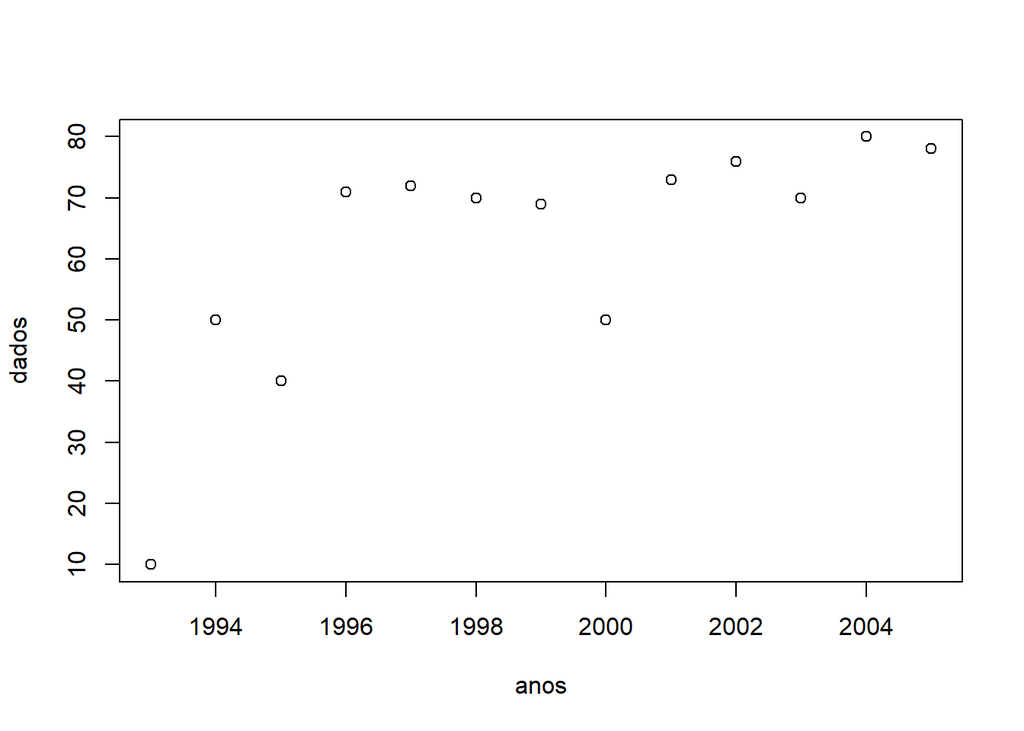

### feedback

Testes de correlação.

# Capítulo 5.2 - maças, biologia, indústria - ESSAY

## variante única

Considere o estudo de regressão linear aplicado aos dados (x=ano,Y=número de novos produtos). A tabela de coeficientes é a seguinte:

```
Coefficients:
             Estimate Std. Error t value Pr(>|t|)
(Intercept) -7351.643   2108.285  -3.487  0.00509
anos            3.709      1.055   3.517  0.00483
```

**(i)** Qual a equação de reta? Indique o que significam os coeficientes.

**(ii)** Para o ano 2000 qual o valor esperado para o número de novos produtos?

**(iii)** Qual o valor do resíduo ( erro, \(\epsilon\) ) para esse ano?

**(iv)** O que pode concluir com os valores da seguinte tabela?

```
Residuals:
    Min      1Q  Median      3Q     Max
-29.978  -7.066   2.643   6.769  19.8
```

# Capítulo 6 - Teste de Independência - CLOZE

- Teste ao gerador de tabelas html: https://www.tablesgenerator.com/html_tables

## variante única

Pretende-se avaliar se, em Portugal, existe dependência entre o tipo de agricultura que se pratica (biológica ou de cariz industrial) e a localização (norte, centro e sul). Num encontro de empresários agrícolas foram inquiridos 177 empresários selecionados ao acaso. Os resultados estão condensados na seguinte tabela de contingência:

[output not shown]

**(i)** Complete, justificando, a seguinte tabela de frequências esperadas sob a validade da hipótese de independência entre a localização e o tipo de agricultura:

| esperadas | Biológica | Indústria |
| --- | --- | --- |
| norte | AAA | 28.58757 |
| centro | 24.01130 | 25.98870 |
| sul | 34.57627 | 37.42373 |

O valor de AAA é {:NUMERICAL:=26.41243:0.1}.

**(ii)** Com base nos dados recolhidos foi realizado um teste de independência do qui-quadrado sendo o valor observado da estatística de teste \(\chi^2=2.2368\).

```
    Pearson's Chi-squared test

data:  empresas
X-squared = 2.2368, df = DF, p-value = VALOR-P
```

O valor-p, em falta na tabela acima, é {:NUMERICAL:=0.3268:0.01}

### feedback

(Consulte o docente.)